# Steak Preferences in the United States

Summary Report For the **Mountain** Region

Author: Melinda K. Higgins, PhD.

March 21, 2018

## Background

In May 2014, Walt Hickey at [538.com](http://fivethirtyeight.com/) published an article entitled [“How Americans Like Their Steak”](https://fivethirtyeight.com/features/how-americans-like-their-steak/). This article utilized survey data collected from 550 people which asked questions related to various risky activities, such as whether they speed in traffic, if they smoke or go skydiving, and if they prefer a riskier lottery. The survey also asked if they eat steak and if so, how they prefer their steak.

## Purpose

The “steak survey” dataset that was used for the [“How Americans Like Their Steak”](https://fivethirtyeight.com/features/how-americans-like-their-steak/) article, is available through the R package [`fivethirtyeight`](https://cran.r-project.org/web/packages/fivethirtyeight/index.html). Using this dataset, this article summarizes the steak preferences for the **Mountain** Region of the United States by gender.

For our summary presented here, a subset of the original steak survey was extracted to only include responses with no missing data and only included respondents from the **Mountain** region of the US. The data subset used for our summary had 40 respondents.

## Demographic Summary Tables - Age

The age categories of the 40 survey respondents were:

Ages of Survey Respondents

| Ages | % |
| --- | --- |
| 18-29 | 20.0 |
| 30-44 | 27.5 |
| 45-60 | 35.0 |
| > 60 | 17.5 |

## Steak Preparation Preference by Gender

Finally, here is a breakdown of the 40 survey respondents for the **Mountain** region of the US on how they prefer their steak to be prepared by gender.

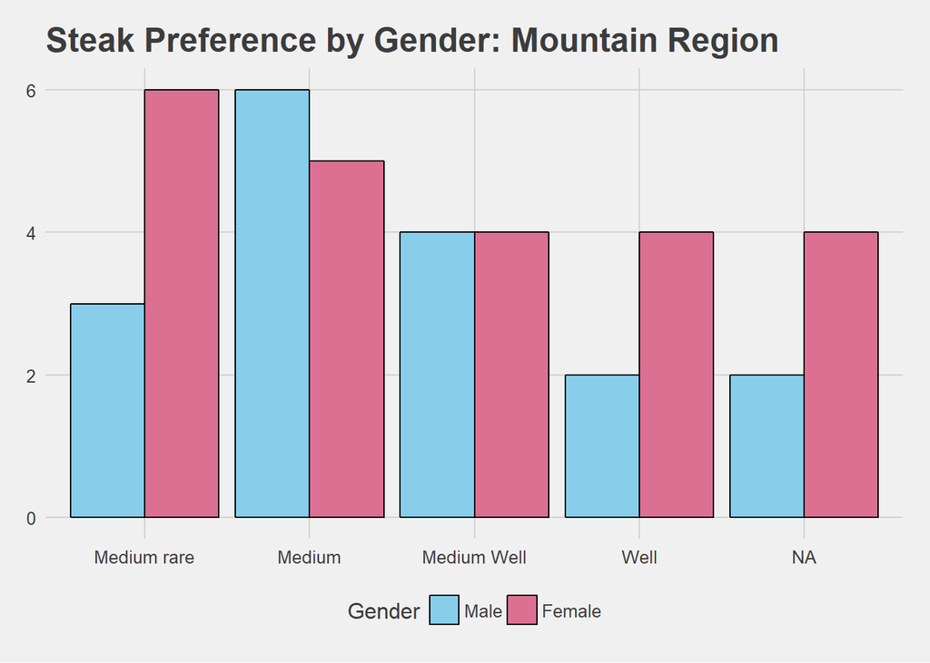